# Problem Set 4 Exploring Two Variables

## Set up

Go to working directory Load the ggplot package

```r
#setwd("D:/DOCUMENTS/LEARNING/DAND/DAND4 EDA - R/PS4_Two_Var")
```

**Load the diamonds data set in RStudio**  
As a reminder, you can use these commands to load the diamonds data set. Some data sets come with R. You can load these data sets by typing `data(DATA_SET_NAME)`. The “diamonds” data set comes with the *ggplot* package.

```r
library(ggplot2)
data(diamonds)
names(diamonds)
```

```
##  [1] "carat"   "cut"     "color"   "clarity" "depth"   "table"   "price"
##  [8] "x"       "y"       "z"
```

```r
str(diamonds)
```

```
## Classes 'tbl_df', 'tbl' and 'data.frame':    53940 obs. of  10 variables:
##  $ carat  : num  0.23 0.21 0.23 0.29 0.31 0.24 0.24 0.26 0.22 0.23 ...
##  $ cut    : Ord.factor w/ 5 levels "Fair"<"Good"<..: 5 4 2 4 2 3 3 3 1 3 ...
##  $ color  : Ord.factor w/ 7 levels "D"<"E"<"F"<"G"<..: 2 2 2 6 7 7 6 5 2 5 ...
##  $ clarity: Ord.factor w/ 8 levels "I1"<"SI2"<"SI1"<..: 2 3 5 4 2 6 7 3 4 5 ...
##  $ depth  : num  61.5 59.8 56.9 62.4 63.3 62.8 62.3 61.9 65.1 59.4 ...
##  $ table  : num  55 61 65 58 58 57 57 55 61 61 ...
##  $ price  : int  326 326 327 334 335 336 336 337 337 338 ...
##  $ x      : num  3.95 3.89 4.05 4.2 4.34 3.94 3.95 4.07 3.87 4 ...
##  $ y      : num  3.98 3.84 4.07 4.23 4.35 3.96 3.98 4.11 3.78 4.05 ...
##  $ z      : num  2.43 2.31 2.31 2.63 2.75 2.48 2.47 2.53 2.49 2.39 ...
```

```r
?diamonds
```

```
## starting httpd help server ...
```

```
##  done
```

In this problem set, you’ll continue to explore the diamonds data set.

### PS 4-1 price vs x

Your first task is to create a scatterplot of price vs x using the ggplot syntax.

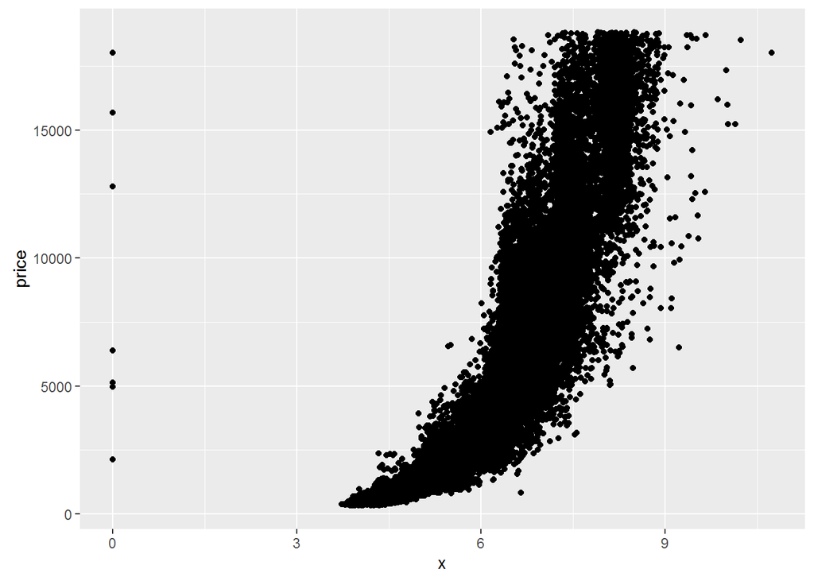

```r
ggplot(aes(x = x, y = price), data = diamonds) +
  geom_point()
```

### PS 4-2 Findings - price vs x

Price rises with x slightly until an x of about 6 or 6.5. In that range, price almost never is above $5000. Then, at x’s above that. price varies much more .

Answer: **Did you notice some outliers, and an exponential relationship between prince and x?**

### PS 4-3 Correlations

```r
cor.test(diamonds$price, diamonds$x)
```

```
##
##  Pearson's product-moment correlation
##
## data:  diamonds$price and diamonds$x
## t = 440.16, df = 53938, p-value < 2.2e-16
## alternative hypothesis: true correlation is not equal to 0
## 95 percent confidence interval:
##  0.8825835 0.8862594
## sample estimates:
##       cor
## 0.8844352
```

```r
cor.test(diamonds$price, diamonds$y)
```

```
##
##  Pearson's product-moment correlation
##
## data:  diamonds$price and diamonds$y
## t = 401.14, df = 53938, p-value < 2.2e-16
## alternative hypothesis: true correlation is not equal to 0
## 95 percent confidence interval:
##  0.8632867 0.8675241
## sample estimates:
##       cor
## 0.8654209
```

```r
cor.test(diamonds$price, diamonds$z)
```

```
##
##  Pearson's product-moment correlation
##
## data:  diamonds$price and diamonds$z
## t = 393.6, df = 53938, p-value < 2.2e-16
## alternative hypothesis: true correlation is not equal to 0
## 95 percent confidence interval:
##  0.8590541 0.8634131
## sample estimates:
##       cor
## 0.8612494
```

### PS 4-4, 4-5 price vs depth

Create a simple scatterplot of price vs depth. Then change the code to make the transparency of the points to be 1/100 of what they are now and mark the x-axis every 2 units.

`?diamonds` What is depth?:  
total depth percentage = z/mean(x, y) = 2*z/(x + y)(43â“79)

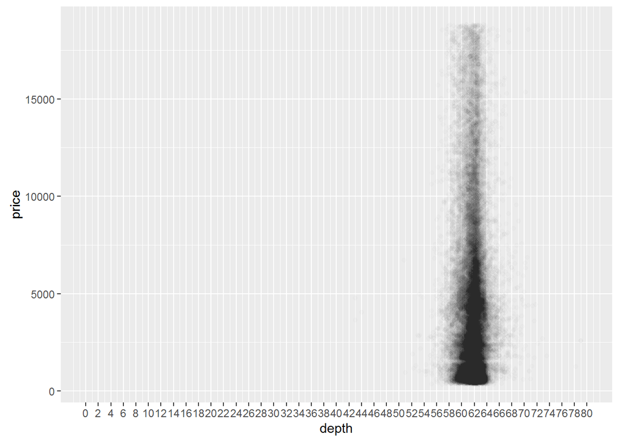

```r
ggplot(aes(x = depth, y = price), data = diamonds) +
  geom_point(alpha = 0.01) +
  scale_x_continuous(limits = c(0, 80), breaks = seq(0, 80, 2))
```

### PS 4-6 Typical Depth Range

Based on the scatterplot, most diamonds are between what values of depth?  
59 to 64

### PS 4-7, Correlation - price and depth

Correlation of depth and price?

```r
cor.test(diamonds$price, diamonds$depth)
```

```
##
##  Pearson's product-moment correlation
##
## data:  diamonds$price and diamonds$depth
## t = -2.473, df = 53938, p-value = 0.0134
## alternative hypothesis: true correlation is not equal to 0
## 95 percent confidence interval:
##  -0.019084756 -0.002208537
## sample estimates:
##        cor
## -0.0106474
```

-0.01

Based on the correlation coefficient, would yo use depth to predict the price of a diamond?  
No. It’s within -.2 and +.2, and very near 0.

### PS 4-8 price vs carat

Create a scatterplot of price vs carat and omit the top 1% of price and carat values.

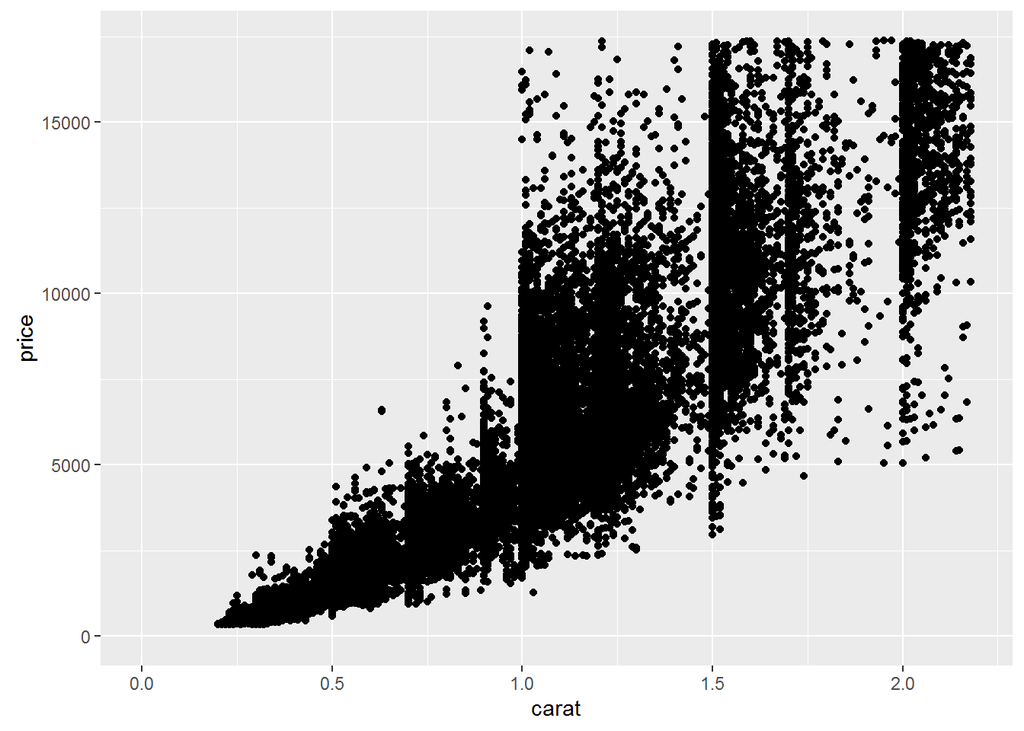

```r
ggplot(aes(x = carat, y = price), data = diamonds) +
  geom_point() +
  xlim(0, quantile(diamonds$carat, 0.99)) +
  ylim(0, quantile(diamonds$price, 0.99))
```

Does the x-axis extend beyond 2? It should!

### PS 4-9 price vs volume

1 - Create a scatterplot of price vs. volume (x * y * z). This is a very rough approximation for a diamond’s volume.

2 - Create a new variable for volume in the diamonds data frame. This will be useful in a later exercise.

Don’t make any adjustments to the plot just yet.

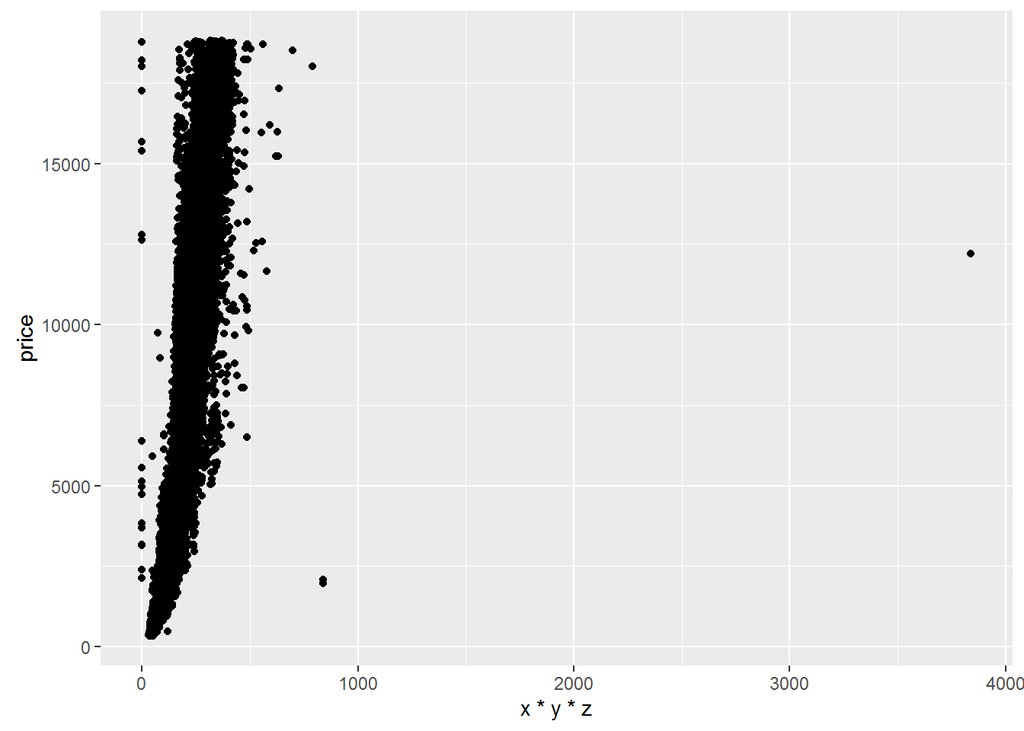

```r
ggplot(aes(x = x*y*z, y = price), data = diamonds) +
  geom_point()
```

```r
diamonds$volume <- with(diamonds, x*y*z)
```

PS 4-10, What are your observations from the price vs volume scatterplot?  
Me: Almost no volumes over 400. A few strange outliers – 0 volume, 3800 volume. Price increase exponentially between 0 and about 400 volume.

4-10 INSTRUCTOR ANSWER:  
Did you notice some outliers? Some volumes are 0! There’s an expensive diamond with a volume near 4000, and a cheaper diamond with a volume near 900.

You can find out how many diamonds have 0 volume by using  
`count(diamonds$volume == 0)`

The count() function comes with the plyr package. If you ran the count function from plyr, you need to run this command in R to unload the plyr package.  
`detach("package:plyr", unload=TRUE)` because the plyr package will conflict with the dplyr package in later exercises.

**Takeaway – Depending on your investigation, it may or may not be important for you to understand how outliers, like these, *came to be in* your data.**

### PS 4-11, Correlations on Subsets

What’s the correlation of price and volume?  
Exclude diamonds that have a volume of 0 and of 800 and greater. Round answer to two decimal places.

```r
with(subset(diamonds, volume > 0 & volume <= 800) , cor.test(price, volume))
```

```
##
##  Pearson's product-moment correlation
##
## data:  price and volume
## t = 559.19, df = 53915, p-value < 2.2e-16
## alternative hypothesis: true correlation is not equal to 0
## 95 percent confidence interval:
##  0.9222944 0.9247772
## sample estimates:
##       cor
## 0.9235455
```

Hint 1: Add a variable for volume to the diamonds data frame. [Done]. Use the `&` symbol between two conditions when you subset the original data frame.

Hint 2: Subset the diamonds data frame under the conditions and save it into another variable. Use that data frame in the cor() function.

```r
volsub = subset(diamonds, volume > 0 & volume <= 800)
with(volsub, cor.test(price, volume))
```

```
##
##  Pearson's product-moment correlation
##
## data:  price and volume
## t = 559.19, df = 53915, p-value < 2.2e-16
## alternative hypothesis: true correlation is not equal to 0
## 95 percent confidence interval:
##  0.9222944 0.9247772
## sample estimates:
##       cor
## 0.9235455
```

### PS 4-12 Adjustments: price vs volume

Subset the data to exclude diamonds with a volume greater than or equal to 800. Also, exclude diamonds with a volume of 0. Adjust the transparency of the points and add a linear model to the plot. (See the Instructor Notes or look up the documentation of geom_smooth() for more details about smoothers.)

My code, below, assumes that diamonds$volume and the 0 to800 conditions haven’t been created yet.

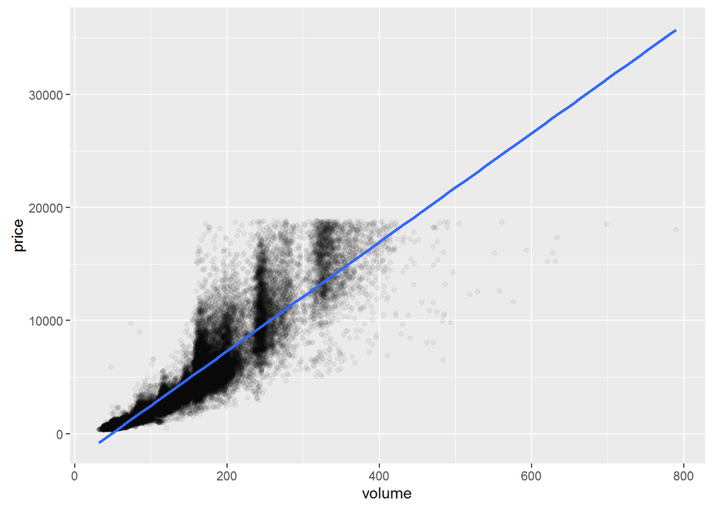

```r
# put a volume variable in the diamonds data set
diamonds$volume <- with(diamonds, x*y*z)

# exclude volumes at 0 or above 800
volume_0_800 = subset(diamonds, volume > 0 & volume <= 800)

ggplot(aes(x = volume, y = price), data = volume_0_800) +
  geom_point(alpha = 1/20) +
  geom_smooth(method = 'lm')
```

Do you think this would be a useful model to estimate the price of diamonds? Why or why not? At first glance, some usefulness, especially at lower volume diamonds. Say, less than 100. I think I’d have to zoom in on different sections of the plot, and also to calculate correlation, to give a more definite answer

[Smoothed, conditional summaries are easy to add to plots in ggplot2. This makes it easy to see overall trends and explore visually how different models fit the data.](http://www.ats.ucla.edu/stat/r/faq/smooths.htm)

### PS 4-13 Mean Price by Clarity

Use the **dplyr** package to create a new data frame containing info on diamonds by clarity. Name the data frame “diamondsByClarity”.

The data frame should contain the following variables in this order:  
1. mean_price 2. median_price 3. min_price 4. max_price 5. n, where n is the number of diamonds in each level of clarity

My ref – See ‘lesson4_student.rmd’: “13, 14 Conditional Means”)

```r
suppressMessages(library(dplyr))
# group data by clarity
clarityGroup <- group_by(diamonds, clarity)
# new data frame as specified by instructions
diamondsByClarity <- summarise(clarityGroup,
                               mean_price = mean(price),
                               median_price = median(price),
                               min_price = min(price),
                               max_price = max(price),
                               n = n())
```

### PS 4-14 Bar Charts of Mean Price

We have created summary data frames with the mean price by clarity and color. You can run the code in R to verify what data is in the variables `diamonds_mp_by_clarity` and `diamonds_mp_by_color`.

- Group the data you want to summarize.
- Summarize it, with a function.
- Graph plot(s) for it.

```r
data(diamonds)
library(dplyr)

diamonds_by_clarity <- group_by(diamonds, clarity)
diamonds_mp_by_clarity <- summarise(diamonds_by_clarity, mean_price = mean(price))

diamonds_by_color <- group_by(diamonds, color)
diamonds_mp_by_color <- summarise(diamonds_by_color, mean_price = mean(price))
```

Your task is to write additional code to create two bar plots on one output image using the grid.arrange() function from the package gridExtra

```r
library(gridExtra)
```

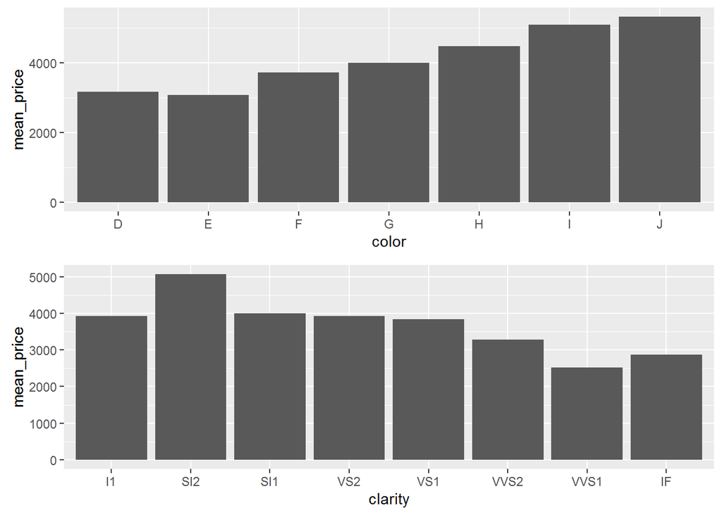

```r
p1 <- ggplot(aes(x = color, y = mean_price), data = diamonds_mp_by_color) +
  geom_bar(stat = 'identity')
p2 <- ggplot(aes(x = clarity, y = mean_price), data = diamonds_mp_by_clarity) +   geom_bar(stat = 'identity')
grid.arrange(p1, p2)
```

Notes:  
[geom_bar Reference](http://docs.ggplot2.org/current/geom_bar.html)  
“By default, `geom_bar` uses stat=”count" which makes the height of the bar proportional to the number of cases in each group…. *If you want the heights of the bars to represent **values in the data**, use **stat=“identity”** and map a variable to the y aesthetic.*" (emph. mine, bec. I DID want bar height to represent values in the data - ‘mean price’ in this case.)

Instructor notes refer us to http://flowingdata.com/2014/02/27/how-to-read-histograms-and-use-them-in-r/, but I found the ggplot reference, plus Udacity forums, to be more helpful.

So, what’s going on here:  
1. Set up and arrange or rearrange the data that you want to examine, in the way and order you want to examine it.  
2. Make a plot or plots appropriate for that data.